# Stirb langsam, Anna

## Enrique Mazzola und David Alden inszenieren ANNA BOLENA, Donizettis Meisterwerk des Belcanto. Ein Gespräch über Gewalt, Ohnmacht und die wohl längste Schlussarie der Opernwelt

[figure not shown]

Anna Bolena © Toni Suter, Opernhaus Zürich

[figure not shown]

Anna Bolena © Toni Suter, Opernhaus Zürich

[figure not shown]

Anna Bolena © Toni Suter, Opernhaus Zürich

[figure not shown]

Anna Bolena © Toni Suter, Opernhaus Zürich

[figure not shown]

Anna Bolena © Toni Suter, Opernhaus Zürich

[figure not shown]

Anna Bolena © Toni Suter, Opernhaus Zürich

[figure not shown]

Anna Bolena © Toni Suter, Opernhaus Zürich

[figure not shown]

Anna Bolena © Toni Suter, Opernhaus Zürich

[figure not shown]

Anna Bolena © Toni Suter, Opernhaus Zürich

[figure not shown]

Anna Bolena © Toni Suter, Opernhaus Zürich

[figure not shown]

Anna Bolena © Toni Suter, Opernhaus Zürich

[zurück](https://deutscheoperberlin.de/de_DE/blog)

[Anna Bolena](https://deutscheoperberlin.de/de_DE/production/anna-bolena.1340462)

**Herr Alden, Herr Mazzola, Sie bringen mit ANNA BOLENA die erste Oper der Tudor-Trilogie von Gaetano Donizetti auf die Bühne der Deutschen Oper Berlin. Was fasziniert Sie an diesem Stück?**

David Alden: Ich habe immer davon geträumt, die Trilogie und speziell ANNA BOLENA zu inszenieren. Ich liebe Donizetti und interessiere mich sehr für den Belcanto-Stil. Nicht nur weil die Musik fantastisch ist, die Stücke sind auch extrem gut erzählt. Ich glaube, man hat das lange unterschätzt, dachte, Belcanto sei nur etwas für Melomanen, für Menschen, die besessen sind von Stimmen und Koloraturen. Und natürlich stimmt das auch, aber eben nicht nur. Die Stimmen sind das Herzstück des Genres, die Sänger*innen können hier wirklich alles geben: Anna singt in der Schlussszene ein fast dreißigminütiges Monodrama, in dem sie alle erdenklichen Gefühlslagen durchlebt, bevor man sie tötet. Das ist wahnsinnig stark. Aber eben nicht nur auf stimmlicher, sondern auch auf dramatischer Ebene. Es ist großes Theater.

Enrique Mazzola: Mich begeistert an ANNA BOLENA, dass wir hier ein Genre auf seinem Höhepunkt erleben können, reinen Belcanto. Die Oper ist 1830 entstanden, damals war Bellini der Superstar am Belcanto-Himmel und Donizetti wollte sich mit dieser Oper beweisen. Man kann sich das vorstellen wie, sagen wir, eine debütierende Lady Gaga, die sich neben einer Ikone wie Madonna einen Platz verschaffen will: Donizetti hatte die einmalige Chance, im Teatro Carcano in Mailand in derselben Saison seine Uraufführung zu feiern wie Bellini mit LA SONNAMBULA. Der Druck muss enorm gewesen sein. Er wollte etwas wirklich Außergewöhnliches komponieren – und es ist ihm gelungen.

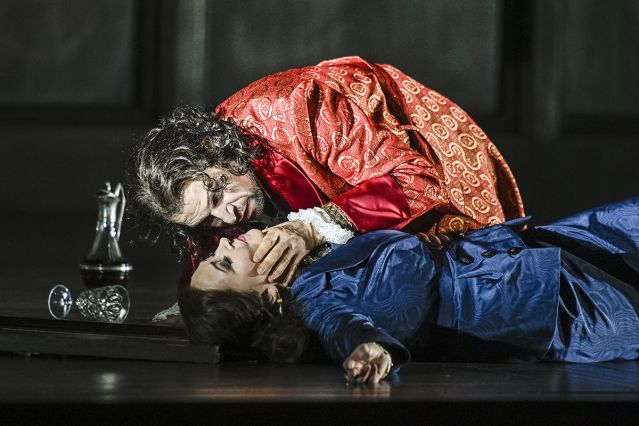

König Heinrich bedroht seine Verlobte Jane Seymour, weil sie es gewagt hat, um Gnade für Anne Boleyn zu bitten. © Toni Suter, Opernhaus Zürich

**Sie haben gesagt, es sei die komplexeste Oper der Trilogie. Warum?**

Mazzola: Es ist definitiv die »angeberischste« der drei Opern. Im besten Sinne des Wortes. Donizetti wollte zeigen, was er kann: Es ist die Oper mit den längsten Rezitativen, den längsten und komplexesten Szenen. ANNA BOLENA war ein Ausweis seiner Könnerschaft, und es wurde sein ganz großer Durchbruch, hat ihn zu einem Hauptvertreter seines Genres werden lassen.

**Komplexität allein erklärt noch keinen Welterfolg. Wieso war ANNA BOLENA so beliebt beim Publikum?**

Mazzola: Wohl wegen ihrer emotionalen Intensität. Das zeigt sich vor allem in diesem unglaublichen Finale, das David schon erwähnte. Das hatte es bis dahin noch nicht gegeben, die Schlussszene verlangt der Sängerin eine enorme Kraft ab. Den Belcanto zeichnet generell aus, dass sich das Orchester zurückhält. Es begleitet die Stimme, aber lenkt nie von ihr ab. Die Musik sagt nie: Angst, Wut, Liebe. Sie überlässt es ganz den Sängern, eine Fülle an Emotionen nur über die Stimme zu transportieren. Donizetti ist das mit ANNA BOLENA auf außergewöhnliche Weise gelungen.

**Es gibt diesen legendären Auftritt von 1957: Maria Callas singt die Anna in der Mailänder Scala und bringt das in Vergessenheit geratene Stück zurück ins Repertoire. Braucht es eine Diva für diese Rolle?**

Alden: Ja und nein. Es braucht eine sehr kraftvolle und ausdrucksstarke Stimme. Die haben wir.

Mazzola: Ich finde auch, dass wir nicht zu bescheiden sein sollten. Wir sagen oft, heute gebe es keine Diven wie die Callas mehr. Das ist so nicht richtig. Wir haben diese Sängerinnen, sowohl was Stimme als auch Persönlichkeit angeht.

**Orientieren Sie sich an einer solchen Referenzaufnahme?**

Alden: Wissen sie, ich habe ANNA BOLENA tatsächlich durch die Aufnahme von Maria Callas entdeckt. Es war quasi das erste Mal seit dem 19. Jahrhundert, dass diese Oper überhaupt wiederaufgeführt wurde. Allerdings sang Callas sie in sehr gekürzter Form. Das war damals üblich, man stutzte die Stücke für das moderne Publikum zusammen. Ich finde das schade. Zwar ist die Länge durchaus eine Herausforderung, aber sie macht eben auch den Reiz dieser Oper aus. Nicht wahr, Enrique?

Mazzola: Genau. Wir wollen dem Publikum einen möglichst authentischen Eindruck davon geben, was diese Oper für uns ausmacht. Ich habe großen Respekt vor den Sängerinnen und Sängern, die uns dieses Stück zurückgebracht haben, trotzdem scheint ihre Herangehensweise nicht mehr zeitgemäß. Damals ließ man in gewisser Weise alle Momente weg, in denen der Star nicht glänzte, heute wirken diese Schnitte recht brutal. Deshalb haben David und ich versucht, wenig zu kürzen und eine möglichst originalgetreue Version anzubieten.

**Herr Alden, Sie sind dafür bekannt, historisches Material in die Gegenwart zu übersetzen. Inwieweit haben Sie den Stoff aktualisiert?**

Alden: Sehr wenig. Es hat berühmte Produktionen gegeben, in denen die Donizetti-Trilogie in die Jetztzeit übersetzt wurde, und das war auch sehr gut und für die damalige Zeit perfekt. Nur hatte ich den Eindruck, dass es heute nicht notwendig ist. Ich glaube, man kann die Parallelen selbst knüpfen. Man kann sich für die Figuren begeistern und sie nicht nur als historische Persönlichkeiten, sondern als echte Menschen sehen. Als Menschen, die mit sehr komplexen, erotisch-politisch motivierten Problemen zu kämpfen haben. Mir scheint der Stoff sehr zeitgenössisch, einfach weil die Gefühle zeitlos und die Beziehungen zwischen den Figuren wahnsinnig spannend sind.

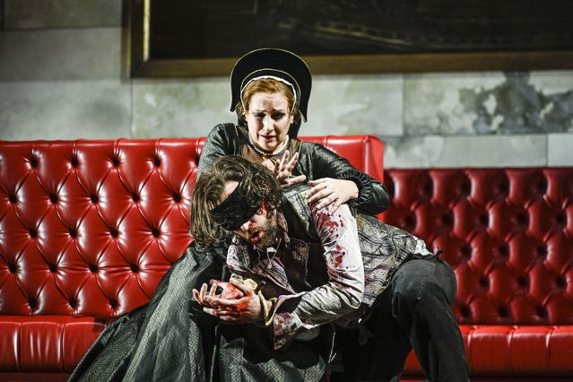

Zeitlose Geschichten um Liebe, Verrat und Macht: Lord Percy in den Armen seiner geliebten Königin Anna, nachdem ihm unter Folter das Geständnis der Affäre abgerungen wurde © Toni Suter, Opernhaus Zürich

**Das britische Königshaus fasziniert seit Jahrhunderten. Wie erklären Sie sich dieses anhaltende Interesse?**

Alden: Sagen wir es so: Wer auch immer die Skripte für die Royals schreibt, ist ein fantastischer Autor. Zumal sich die Geschichten um Liebe, Verrat und Macht immer zu wiederholen scheinen. Wenn Sie so wollen, war Anne Boleyn die Meghan Markle ihrer Zeit. Als wir begannen, an der Oper zu arbeiten, war Markle permanent in den Medien, und ich dachte mir immer wieder: Wie stark sind diese Parallelen doch. Je mächtiger sie wurde, je mehr Einfluss sie auf ihren Mann und die öffentliche Meinung zu haben schien, umso mehr versuchte man sie rauszudrängen. Man wird sie natürlich nicht köpfen, wie man das mit Anne machte, aber die Geste, der Wunsch sie loszuwerden, ist nicht unähnlich.

**Anna wird von ihrem Ehemann, König Heinrich VIII., des Ehebruchs beschuldigt und hingerichtet, weil er eine neue Ehe eingehen will. Inwieweit wird sich ein zeitgenössisches Publikum mit diesem recht archaischen Geschlechterverhältnis identifizieren können?**

Alden: Donizetti zeigt viel Empathie für die Frauen in seiner Oper, sowohl für Anna Bolena als auch für Annas Hofdame Giovanna, die vom König gewissermaßen dazu getrieben wird, ihre Königin zu verraten, obwohl sie sie liebt und bewundert. Die Opern der Trilogie handeln von Frauen, die um ihren Stand in einer männerdominierten Gesellschaft kämpfen. Das bietet immer noch Identifikationspotenzial.

**Anna hat ihre Jugendliebe Henry Percy verlassen, um den König zu heiraten. Nun wird ihr das zum Verhängnis. Kann man sagen, es geht hier um das Dilemma: Liebe oder Macht?**

Alden: Ich würde eher sagen, es geht darum, wie verwoben Macht und Liebe sind. Hier gibt es nicht die Liebe auf der einen Seite und die Macht auf der anderen, beides fließt ineinander über. Liebe ist gefährlich und komplex, genau das thematisiert die Oper. Und genau das macht sie so zeitlos.

*Interview: Annabelle Hirsch. Hirsch arbeitet als freie Journalistin u. a. für FAS/FAZ, Taz, ZeitOnline, schreibt Sachbücher und ist literarische Übersetzerin aus dem Französischen*

Verwandte Themen

Belcanto

Donizetti

[Im Interview](https://deutscheoperberlin.de/de_DE/blog?tag=Im%20Interview)